# Beyond the choropleth

“World data on a map” has many honest forms. A choropleth is only the first. The package offers a full vocabulary; this vignette tours the ones that need only `maps` – itself a suggested package, so the map chunks are skipped when it is absent – and points to the rest, which need `sf` or `biscale` as well.

## Proportional-symbol (bubble) maps

For *totals*, a choropleth misleads: large values hide in small countries. Sized circles at centroids are the right idiom.

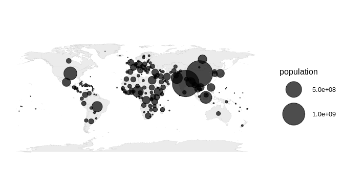

```r
bubble_map(snap, population)
```

## Spike maps

The same “totals” job as bubbles, with a different overplotting trade-off: spikes only grow upward, so dense regions (Europe, the Caribbean) stay legible.

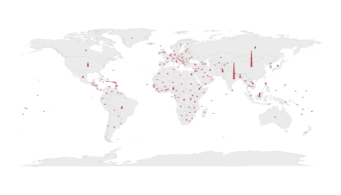

```r
spike_map(snap, population)
```

Both verbs place one symbol per country centroid, and the bundled centroid table does not cover every code in the codelist. On this snapshot five countries with population – Hong Kong, Macao, Gibraltar, the British Virgin Islands and Tuvalu – have no centroid and so no symbol. Each verb warns and names them, and counts them as missing rather than shown:

```r
cov <- attr(suppressWarnings(bubble_map(snap, population)),
            "countryatlas_provenance")$coverage
unlist(cov[c("n_total", "n_shown", "n_missing")])
```

```
#>   n_total   n_shown n_missing
#>       215       210         5
```

```r
cov$missing_iso3c
```

```
#> [1] "GIB" "HKG" "MAC" "TUV" "VGB"
```

## Equal-area tile grids

Give every country the same visual weight so micro-states are visible. The bundled grid covers 239 countries – see `?world_tiles` for the ten it omits.

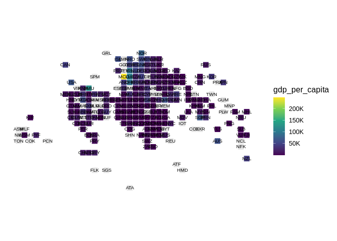

```r
tile_map(snap, gdp_per_capita)
```

## Flow maps

Great-circle arcs between country pairs from an origin–destination table.

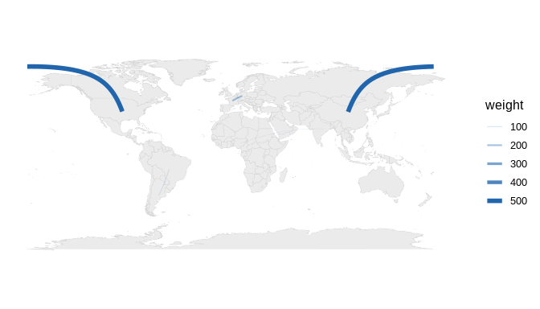

```r
od <- data.frame(
  from   = c("China", "Germany", "Brazil", "Nigeria"),
  to     = c("United States", "France", "Argentina", "India"),
  weight = c(500, 200, 90, 60)
)
flow_map(od, from, to, weight)
```

## Small multiples

`facet_map()` splits one choropleth into per-group panels, the static counterpart to `animate_world()`, for print and side-by-side comparison:

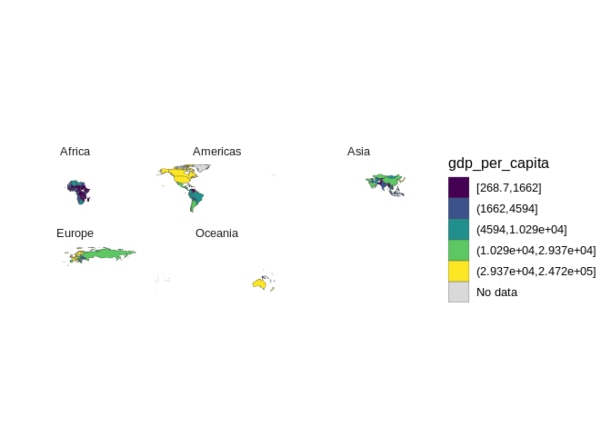

```r
world_poly <- attach_geometry(snap, geometry = "polygon") |>
  dplyr::filter(!is.na(continent))
facet_map(world_poly, gdp_per_capita, continent, style = "quantile", ncol = 3)
```

## Labels

Centroid-anchored labels (names, ISO codes or flag emoji), with `ggrepel` collision avoidance when available. Zoom with `coord_quickmap()` rather than `coord_cartesian()` – both replace the map’s coordinate system, but only the former keeps the latitude-dependent aspect ratio that stops Europe coming out stretched sideways.

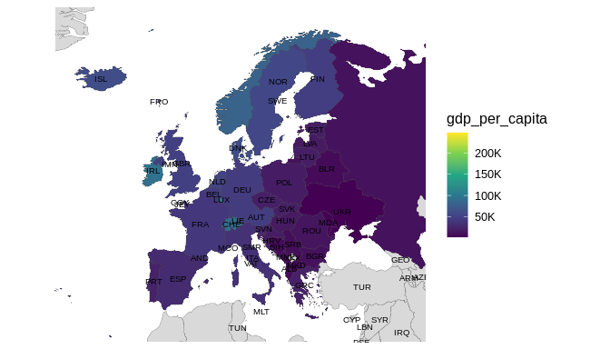

```r
mapdf <- attach_geometry(
  dplyr::filter(snap, continent == "Europe"), geometry = "polygon"
)
world_map(mapdf, gdp_per_capita) +
  geom_country_labels(repel = FALSE, size = 2.5) +
  ggplot2::coord_quickmap(xlim = c(-25, 45), ylim = c(34, 72))
```

## Maps that need optional packages

The remaining displays follow the same one-call pattern but require optional packages, so they are shown here as code:

```r
# Bivariate choropleth (two variables at once): needs `biscale` + `sf`
world_data(2020, c(gdp = "NY.GDP.PCAP.KD", life = "SP.DYN.LE00.IN"),
           geometry = "sf") |>
  bivariate_map(gdp, life)

# Area-honest cartogram: needs `cartogram` + `sf`
world_data(2020, c(pop = "SP.POP.TOTL"), geometry = "sf") |>
  cartogram_map(pop, type = "dorling")

# The same Dorling cartogram as a first-class verb, with its tuning exposed
world_data(2020, c(pop = "SP.POP.TOTL"), geometry = "sf") |>
  dorling_map(pop, k = 4)

# The fast flow-based cartogram (Gastner-Seguy-More): needs `cartogramR`
world_data(2020, c(pop = "SP.POP.TOTL"), geometry = "sf") |>
  cartogram_map(pop, type = "flow")

# Animated choropleth over a year panel: needs `gganimate`
world_data(2000:2020, c(gdp = "NY.GDP.PCAP.KD")) |>
  animate_world(gdp)

# Interactive choropleth: needs `leaflet`, `ggiraph` or `plotly`
world_data(2020) |>
  interactive_map(gdp_per_capita, engine = "plotly")
```

## Value-by-alpha: the cartogram’s non-distorting cousin

A cartogram equalises a denominator by deforming geometry. `value_by_alpha_map()` does it by spending opacity instead, so the world stays recognisable: colour carries the value, opacity carries population, and a rate computed over a handful of people fades toward the background rather than shouting.

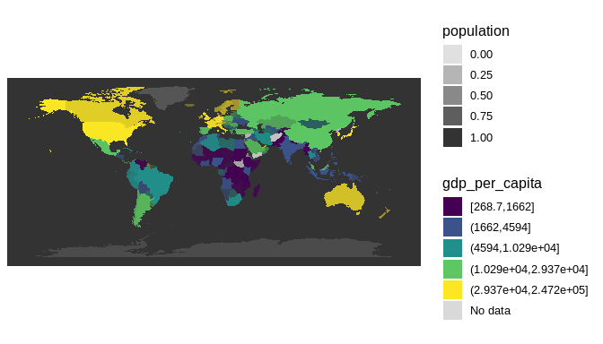

```r
mapdf <- attach_geometry(snap, geometry = "polygon")
value_by_alpha_map(mapdf, gdp_per_capita, population)
```

It needs no optional packages. The *Honest maps* vignette covers when to reach for it rather than for `cartogram_map()`.

## Country adjacency and distance

Two lightweight spatial helpers that aren’t choropleths at all. `distance_between()` answers “how far apart” from the bundled `country_meta` centroids, with no `sf` or network required:

```r
distance_between("France", "Germany")
```

```
#> [1] 802.3524
```

`country_borders()` / `neighbors()` answer “who borders whom”, built from polygon topology, so they need `sf`:

```r
neighbors("France")
```

```
#> # A tibble: 8 × 3
#>   iso3c neighbor neighbor_country
#>   <chr> <chr>    <chr>
#> 1 FRA   SUR      Suriname
#> 2 FRA   LUX      Luxembourg
#> 3 FRA   ITA      Italy
#> 4 FRA   BRA      Brazil
#> 5 FRA   DEU      Germany
#> 6 FRA   CHE      Switzerland
#> 7 FRA   BEL      Belgium
#> 8 FRA   ESP      Spain
```

Each degrades gracefully: if the optional package is missing you get a clear, actionable message (and `animate_world()` falls back to a faceted small-multiple).